# Test fm consistency

‘ggpmisc’ 0.6.1.9001

Pedro J. Aphalo

2025-04-17

## Purpose

Package ‘ggpmisc’ makes it easier to add to plots created using ‘ggplot2’ annotations based on fitted models and other statistics. It does this by wrapping existing model fit and other functions. The same annotations can be produced by calling the model fit functions, extracting the desired estimates and adding them to plots. There are two advantages in wrapping these functions in an extension to package ‘ggplot2’: 1) we ensure the coupling of graphical elements and the annotations by building all elements of the plot using the same data and a consistent grammar and 2) we make it easier to annotate plots to the casual user of R, already familiar with the grammar of graphics.

*To avoid confusion it is good to make clear what may seem obvious to some: if no plot is needed, then there is no reason to use this package. The values shown as annotations are not computed by ‘ggpmisc’ but instead by the usual model-fit and statistical functions from R and other packages. The same is true for model predictions, residuals, etc. that some of the functions in ‘ggpmisc’ display as lines, segments, or other graphical elements.*

It is also important to remember that in most cases data analysis including exploratory and other stages should take place before annotated plots for publication are produced. Even though data analysis can benefit from combined numerical and graphical representation of the results, the use I envision for ‘ggpmisc’ is mainly for the production of plots for publication or communication of a completed analysis.

Attaching package ‘ggpmisc’ also attaches package ‘ggpp’ as this package was created as a spin-off from ‘ggpmisc’. ‘ggpp’ provides several of the geometries used by default in the statistics described below. Package ‘ggpp’ can be loaded and attached on its own, and has [separate documentation](https://docs.r4photobiology.info/ggpp/).

## Preliminaries

We load all the packages used in the examples.

```r
library(ggpmisc)
library(nlme)
library(refitME)
```

As we will use text and labels on the plotting area we change the default theme to an uncluttered one.

```r
old_theme <- theme_set(theme_bw())
```

## Fitted models in `stat_poly_line()` and `stat_poly_eq()`

Both functions are designed for flexibility while still attempting to keep their implementation and use rather straightforward.

- Any R function or its name is accepted as argument for `method`.
- The fitted model object must belong to class `"lm"` or to class `"gls"`, as tested with `inherits()`.
- The implementation tolerates some missing fields in model fit objects of a derived class and summary, e.g., `stat_poly_eq()` returns “empty” `character’ labels in such cases.
- The formula used to construct the equation is, whenever possible, extracted from the fitted model object, and only exceptionally, with a warning, the formula passed as argument for `formula` in the call.

This makes it possible to use as `method` existing model fit functions that return an object of a class derived from `"lm"` or `"gls"` or wrapper functions that call such functions, or in some other way return an object of a class derived from `"lm"`.

To showcase this, I explore the use of contributed and user defined model fit functions through examples. The examples use facets or grouping to demonstrate that the models fitted depend on the data, but the approach and functions can be also used with no facets and/or groups to automate the creation of reports or similar.

Some frequently use model fit functions that do not return model fit objects inheriting from class `"lm"` are supported in ‘ggpmisc’ by specific statistics: `stat_ma_line()` and `stat_ma_eq()` for mayor axis regression with package ‘lmodel2’, and `stat_quant_line()`, `stat_quant_band()` and `stat_quant_equation()` for quantile regression with package ‘quantreg’. Their use is documented in the User Guide and their help pages.

## Existing functions

### Robust regression (‘MASS’)

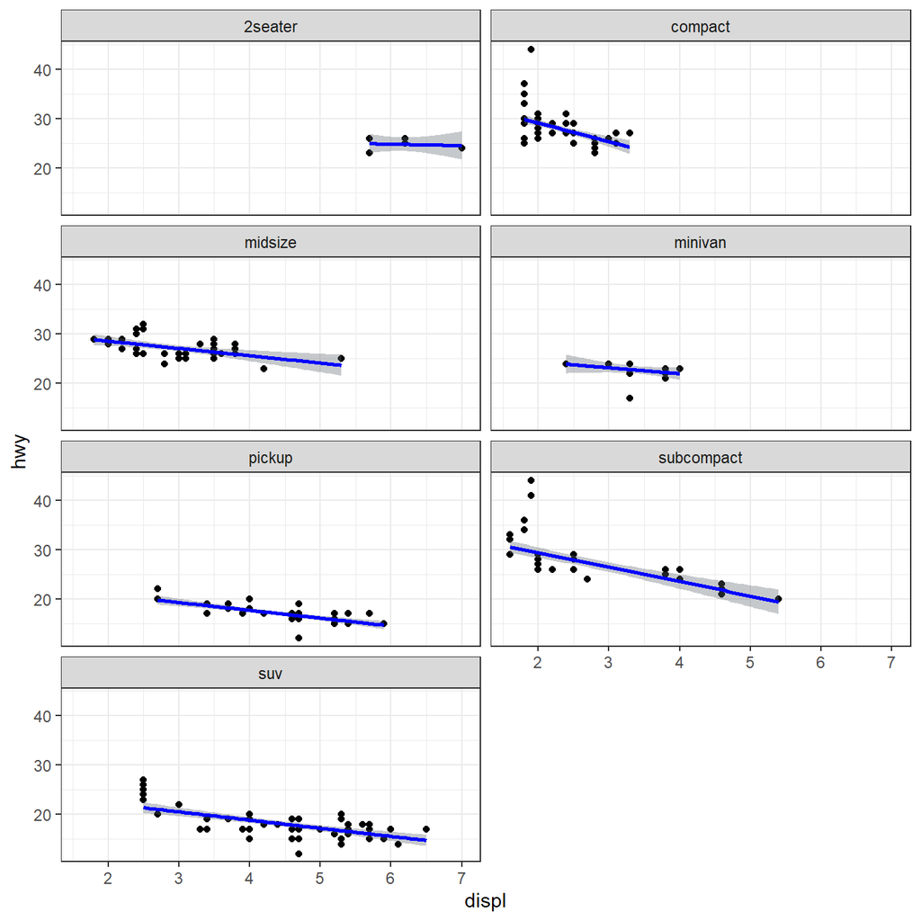

```r
ggplot(mpg, aes(displ, hwy)) +
  geom_point() +
  stat_poly_line(method = MASS::rlm, color = "black", alpha = 0.1) +
  stat_poly_line(method = MASS::rlm, color = "red", fill = "red", alpha = 0.1) +
  stat_poly_line(method = MASS::rlm, color = "green", fill = "green", alpha = 0.1) +
  stat_poly_line(method = MASS::rlm, color = "blue", fill = "blue", alpha = 0.1) +
  facet_wrap(~class, ncol = 2)
```

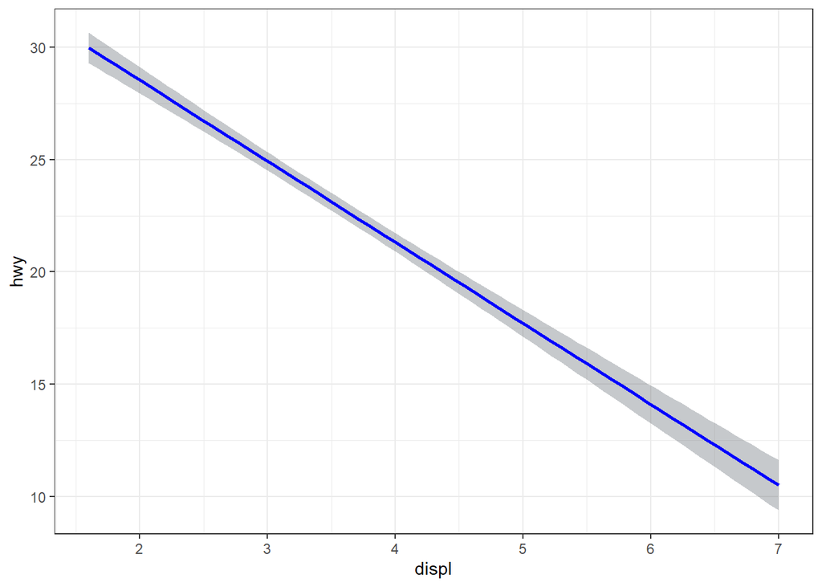

```r
ggplot(mpg, aes(displ, hwy)) +
  stat_poly_line(method = MASS::rlm, color = "black", alpha = 0.1) +
  stat_poly_line(method = MASS::rlm, color = "red", fill = "red", alpha = 0.1) +
  stat_poly_line(method = MASS::rlm, color = "green", fill = "green", alpha = 0.1) +
  stat_poly_line(method = MASS::rlm, color = "blue", fill = "blue", alpha = 0.1)
```

### Robust regression (‘robustbase’)

Package ‘robustbase’ provides function `lmrob()` for “MM-type Estimators for Linear Regression”. The returned value is an `"lmrob"` object. Class `"lmrob"` is derived from `"lm"` so the stats work mostly as expected. However, we need to be aware that no $R^2$ or $P$ estimates are available and the corresponding labels are empty strings.

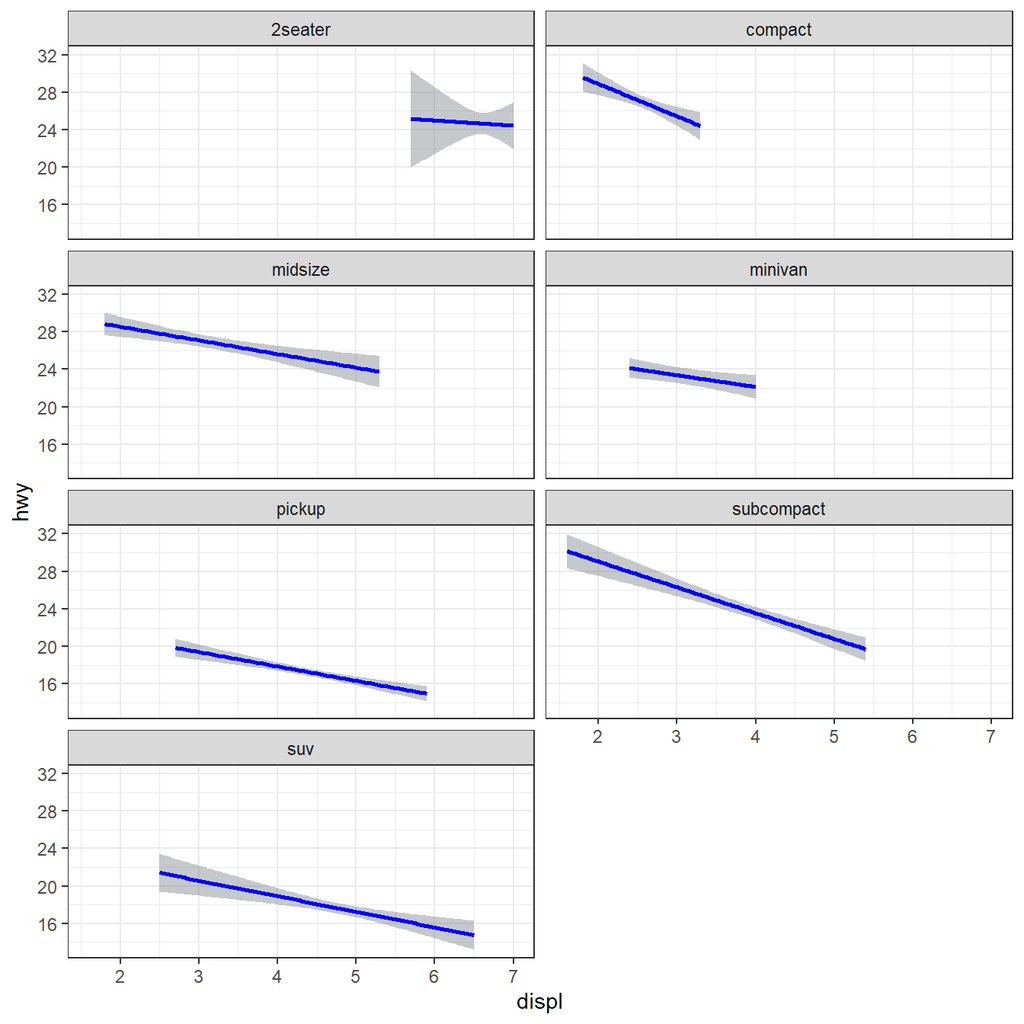

```r
ggplot(mpg, aes(displ, hwy)) +
  stat_poly_line(method = robustbase::lmrob, color = "black", alpha = 0.1) +
  stat_poly_line(method = robustbase::lmrob, color = "red", fill = "red", alpha = 0.1) +
  stat_poly_line(method = robustbase::lmrob, color = "green", fill = "green", alpha = 0.1) +
  stat_poly_line(method = robustbase::lmrob, color = "blue", fill = "blue", alpha = 0.1) +
  facet_wrap(~class, ncol = 2)
```

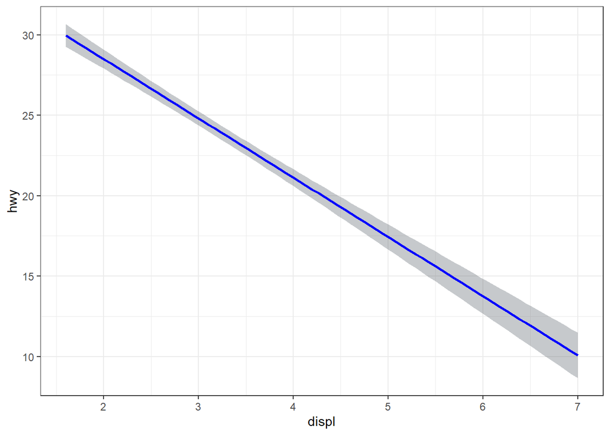

```r
ggplot(mpg, aes(displ, hwy)) +
  stat_poly_line(method = robustbase::lmrob, color = "black", alpha = 0.1) +
  stat_poly_line(method = robustbase::lmrob, color = "red", fill = "red", alpha = 0.1) +
  stat_poly_line(method = robustbase::lmrob, color = "green", fill = "green", alpha = 0.1) +
  stat_poly_line(method = robustbase::lmrob, color = "blue", fill = "blue", alpha = 0.1)
```

### Resistant regression (‘MASS’)

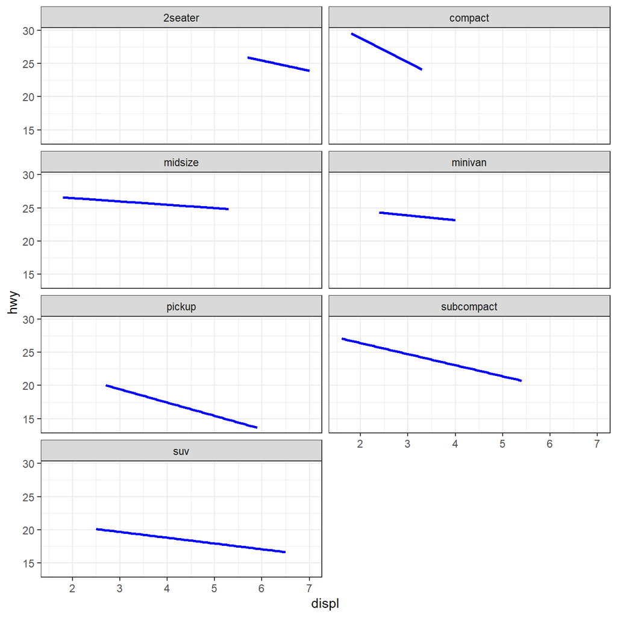

```r
ggplot(mpg, aes(displ, hwy)) +
  stat_poly_line(method = MASS::lqs, se = FALSE, color = "black", alpha = 0.1) +
  stat_poly_line(method = MASS::lqs, se = FALSE, color = "red", fill = "red", alpha = 0.1) +
  stat_poly_line(method = MASS::lqs, se = FALSE, color = "green", fill = "green", alpha = 0.1) +
  stat_poly_line(method = MASS::lqs, se = FALSE, color = "blue", fill = "blue", alpha = 0.1) +
  facet_wrap(~class, ncol = 2)
```

### Generalized Least Squares (‘nlme’)

In ‘ggpmisc’ (>= 0.6.2) function `gls()` from package ‘nlme’ is supported natively by functions `stat_poly_line()` and `stat_poly_eq()`. In this example, using a variance covariate, the computations do not converge with the data in one of the plot panels.

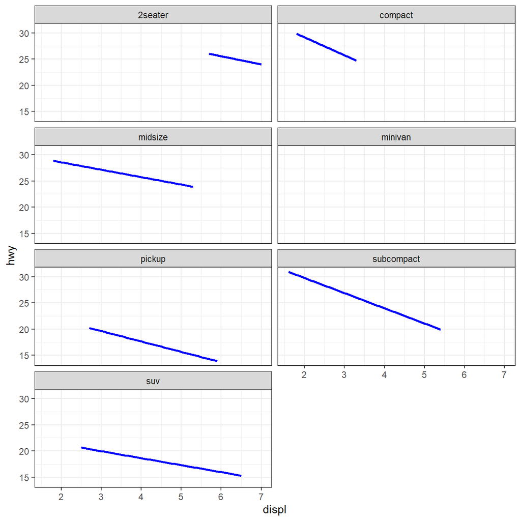

```r
ggplot(mpg, aes(displ, hwy)) +
  stat_poly_line(method = gls,
                  method.args = list(weights = varPower()),
                  color = "black", alpha = 0.1) +
  stat_poly_line(method = gls,
                  method.args = list(weights = varPower()),
                  color = "red", fill = "red", alpha = 0.1) +
  stat_poly_line(method = gls,
                  method.args = list(weights = varPower()),
                  color = "green", fill = "green", alpha = 0.1) +
  stat_poly_line(method = gls,
                  method.args = list(weights = varPower()),
                  color = "blue", fill = "blue", alpha = 0.1) +
   facet_wrap(~class, ncol = 2)
```

## Errors in variables (EIV)

As ‘refitME’ functions return a model fit object of the same class as that received as input, a model fitted with `lm()` could be, in principle, refit in a wrapper functions as those above. However, at the moment the functions in package ‘refitME’ fail when called from within another function.

```r
lm_EIV <- function(formula, data, ..., sigma.sq.u) {
  fm <- lm(formula = formula, data = data, ...)
  MCEMfit_glm(mod = fm, family = "gaussian", sigma.sq.u = sigma.sq.u)
}
```

We then use our function `lm_EIV()` as the method.

```r
ggplot(mpg, aes(displ, hwy)) +
   geom_point() +
   stat_poly_line(method = "lm_EIV", method.args = c(sigma.sq.u = 0)) +
   stat_poly_eq(method = "lm_EIV", method.args = c(sigma.sq.u = 0),
                mapping = use_label("eq"),
   label.x = "right") +
   theme(legend.position = "bottom") +
   facet_wrap(~class, ncol = 2)
```

Produces one warning like below for each call of the statistics.

````
Warning: Computation failed in `stat_poly_eq()`.
Caused by error in `names(new.dat)[c(1, which(names(mod$data) %in% names.w))] <- names(mod$data)[c(1, which(names(mod$data) %in% names.w))]`:
! replacement has length zero```
````

I have reported the problem through a [GitHub issue](https://github.com/JakubStats/refitME/issues/5) to Jakub Stoklosa, the maintainer of ‘refitME’, and he is looking for a permanent solution. Meanwhile, he has provided a temporary fix that I copy below with a few small edits to the ggplot code. Many thanks to Jakub Stoklosa for his very fast answer!

```r
rm(list = ls(pattern = "*"))

library(ggplot2)
library(ggpmisc)
library(refitME)

lm_EIV <- function(formula, data, ..., sigma.sq.u) {
  assign("my.data", value = data, envir = globalenv())
  fm <- lm(formula = formula, data = my.data, ...)
  fit <- refitME(fm, sigma.sq.u)

  fit$coefficients <- Re(fit$coefficients)
  fit$fitted.values <- Re(fit$fitted.values)
  fit$residuals <- Re(fit$residuals)
  fit$effects <- Re(fit$effects)
  fit$linear.predictors <- Re(fit$linear.predictors)
  fit$se <- Re(fit$se)

  if ("qr" %in% names(fit)) {
  fit$qr$qr <- Re(fit$qr$qr)
  fit$qr$qraux <- Re(fit$qr$qraux)
  }

  class(fit) <- c("lm_EIV", "lm")
  return(fit)
}

predict.lm_EIV <- function(object, newdata = NULL, ...) {
  preds <- NextMethod("predict", object, newdata = newdata, ...)

  if (is.numeric(preds)) {
    return(Re(preds))
  } else if (is.matrix(preds)) {
    return(Re(preds))
  } else {
    return(preds) # Leave unchanged if not numeric/matrix
  }
}
```

```
#> [1] 5
#> [1] 11
#> [1] 6
#> [1] 7
#> [1] 6
#> [1] 8
#> [1] 6
#> [1] 5
#> [1] 11
#> [1] 6
#> [1] 7
#> [1] 6
#> [1] 8
#> [1] 6
#> [1] 5
#> [1] 11
#> [1] 6
#> [1] 6
#> [1] 6
#> [1] 8
#> [1] 6
#> [1] 5
#> [1] 10
#> [1] 5
#> [1] 6
#> [1] 6
#> [1] 8
#> [1] 6
```

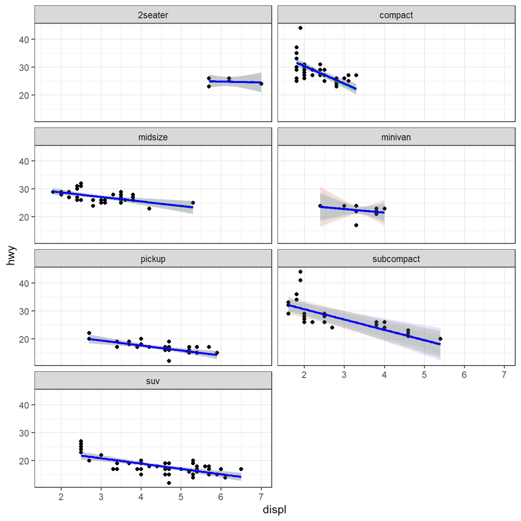

```r
ggplot(mpg, aes(x = displ, y = hwy)) +
  geom_point() +
  stat_poly_line(aes(y = hwy),
                 method = "lm_EIV",
                 method.args = list(sigma.sq.u = 0.01),
                 color = "black", alpha = 0.1) +
  stat_poly_line(aes(y = hwy),
                 method = "lm_EIV",
                 method.args = list(sigma.sq.u = 0.01),
                 color = "red", fill = "red", alpha = 0.1) +
  stat_poly_line(aes(y = hwy),
                 method = "lm_EIV",
                 method.args = list(sigma.sq.u = 0.01),
                 color = "green", fill = "green", alpha = 0.1) +
  stat_poly_line(aes(y = hwy),
                 method = "lm_EIV",
                 method.args = list(sigma.sq.u = 0.01),
                 color = "blue", fill = "blue", alpha = 0.1) +
  facet_wrap(~class, ncol = 2)
```

[output not shown]

[output cut: 23 more lines]

```
#> Warning in summary.lm(mod): essentially perfect fit: summary may be unreliable
#> Warning in summary.lm(mod): essentially perfect fit: summary may be unreliable
#> [1] 71
#> Warning in summary.lm(object, ...): essentially perfect fit: summary may be
#> unreliable
#> [1] 19
#> [1] 20
#> [1] 17
#> [1] 11
#> [1] 40
#> [1] 17
#> [1] 78
#> [1] 17
#> [1] 19
#> [1] 16
```

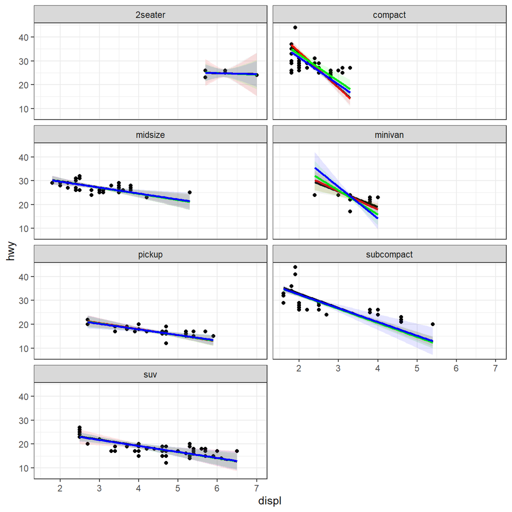

```r
ggplot(mpg, aes(x = displ, y = hwy)) +
  geom_point() +
  stat_poly_line(aes(y = hwy),
                 method = "lm_EIV",
                 method.args = list(sigma.sq.u = 0.1),
                 color = "black", alpha = 0.1) +
  stat_poly_line(aes(y = hwy),
                 method = "lm_EIV",
                 method.args = list(sigma.sq.u = 0.1),
                 color = "red", fill = "red", alpha = 0.1) +
  stat_poly_line(aes(y = hwy),
                 method = "lm_EIV",
                 method.args = list(sigma.sq.u = 0.1),
                 color = "green", fill = "green", alpha = 0.1) +
  stat_poly_line(aes(y = hwy),
                 method = "lm_EIV",
                 method.args = list(sigma.sq.u = 0.1),
                 color = "blue", fill = "blue", alpha = 0.1) +
  facet_wrap(~class, ncol = 2)
```